# 서울특별시 인구수와 문화시설의 상관관계(2014-2017)

김현지

2018년 9월 26일

# 1. 데이터

##### 출처 : [서울열린데이터광장](http://data.seoul.go.kr/)

1. 서울시 주민등록인구 통계(2014-2017)
- 출처 : [서울시 주민등록인구 (연령별/동별) 통계](http://data.seoul.go.kr/dataList/datasetView.do?infId=10727&srvType=S&serviceKind=2)
- 구성 : 자치구 / 동 / 연령 / 인구수 등.
2. 서울시 보육시설 (구별) 통계(1995-2017)
- 출처 : [서울시 보육시설 (구별) 통계](http://data.seoul.go.kr/dataList/datasetView.do?infId=71&srvType=S&serviceKind=2&currentPageNo=1&searchValue=&searchKey=null)
- 구성 : 기간 / 자치구별 / 계 / 국공립 / 사회복지법인 등.

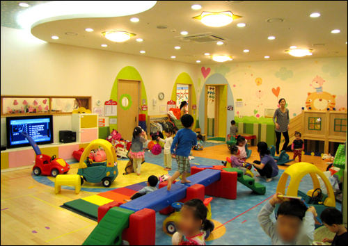

어린이집

3. 서울시 문화공간(영화관) 통계(1993-2017)
- 출처 : [서울시 문화공간(영화관) 통계](http://data.seoul.go.kr/dataList/datasetView.do?infId=165&srvType=S&serviceKind=2&currentPageNo=1&searchValue=&searchKey=null)
- 구성 : 기간 / 자치구 / 개소수 / 스크린수 / 좌석수.

[figure not shown]

영화관

4. 서울시 노인여가 복지시설 통계(2003-2017)
- 출처 : [서울시 노인여가 복지시설(구별) 통계.](http://data.seoul.go.kr/dataList/datasetView.do?infId=54&srvType=S&serviceKind=2)
- 구성 : 기간 / 자치구 / 시설합계 / 노인복지관(시설수 / 종사자수) / 경로당 / 노인교실

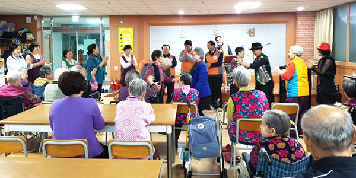

복지시설

# 2. 데이터 선택 이유

- 다른 도시에 비해 서울특별시의 데이터가 보다 기간별로 잘 나타나있었다.
- 해당 데이터에는 기간과 자치구에 따른 문화시설 개수의 변화가 잘 나타나있다.

# 3. 데이터 관련 전문 지식

- 주민등록인구수를 연령별, 행정동별로 제공하는 일반ㆍ보고통계로「주민등록법」에 따른 주민등록표에 등록된 서울시민 및 세대와 「출입국관리법」에 따른 외국인등록표에 등록된 서울시 거주 외국인이 통계로 나타나있다. 지역별 인구의 변동상황 및 연령구조를 파악하여 각 지방행정기관의 제반 행정사항의 기초자료로 활용하는 것을 목적으로 한다.
- 서울시 보육시설 현황을 자치구별로 제공하는 일반ㆍ보고통계로 「영유아보육법」제10조에 의해 설치ㆍ운영되는 보육시설들이 조사되었다. 초등학교 이하 아동의 보육시설 현황 및 이용실태를 파악하여 보육정책 수립 및 평가를 위한 기초자료를 제공하는 것을 목적으로 한다.
- 서울시 문화공간(영화관) 현황을 제공하는 일반ㆍ보고통계로 각종 문화활동을 접하고 참여할 수 있는 문화시설현황 파악을 통해, 시설의 효율적인 관리ㆍ활용을 도모하고 국민의 문화향유 확대 정책 수립을 위한 기초자료로 활용하는 것을 목적으로 한다.
- 서울시 노인여가 복지시설 현황을 자치구별로 제공하는 일반ㆍ보고통계로 「노인복지법」제36조에 의한 노인여가 복지시설이 조사되었다. 노인복지시설 설치신고를 마친 노인복지시설의 수, 입소정원을 집계하여 노인 인구수 대비 적정수의 시설 수요와 충족율을 분석하고 분석결과에 따른 정책 수립 및 평가를 위한 기초자료를 제공하는 것을 목적으로 한다.

# 4. 데이터 분석 방향

연도 및 자치구별을 기준으로 **“영유아 수 - 보육시설 수의 관계”**, **“청년층 수 - 문화공간(영화관) 수의 관계”**, **“노년층 수 - 노인여가 복지시설 수의 관계”** 를 분석하여 해당 연령층의 인구 수가 문화시설 개수에 영향을 주는지 확인한다.